# Clustering

Github Link:https://github.com/angels21/clustering

### Credit Card Customer Segmentation

AllLife Bank wants to focus on its credit card customer base in the next financial year. They have been advised by their marketing research team, that the penetration in the market can be improved. Based on this input, the Marketing team proposes to run personalised campaigns to target new customers as well as upsell to existing customers. Another insight from the market research was that the customers perceive the support services of the back poorly. Based on this, the Operations team wants to upgrade the service delivery model, to ensure that customers queries are resolved faster. Head of Marketing and Head of Delivery both decide to reach out to the Data Science team for help.

### Objectives

To identify different segments in the existing customer based on their spending patterns as well as past interaction with the bank.

### Key Questions

1. How many different segments of customers are there?
2. How are these segments different from each other?
3. What are your recommendations to the bank on how to better market to and service these customers?

### Data Description

Data is of various customers of a bank with their credit limit, the total number of credit cards the customer has, and different channels through which customer hascontacted the bank for any queries, different channels include visiting the bank, online and through a call centre.

### Steps and Tasks

#### Import Libraries

```python
# To enable plotting graphs in Jupyter notebook
%matplotlib inline
```

```python
# Numerical libraries
import numpy as np

from sklearn.model_selection import train_test_split

from sklearn.cluster import KMeans

# to handle data in form of rows and columns
import pandas as pd

# importing ploting libraries
import matplotlib.pyplot as plt

#importing seaborn for statistical plots
import seaborn as sns

from sklearn import metrics

import pandas as pd
```

#### Load and review data

```python
# reading the CSV file into pandas dataframe
data = pd.read_excel('Credit Card Customer Data.xlsx')
```

#### 1. Perform univariate analysis on the data to better understand the variables at your disposal and to get an idea about the no of clusters. Perform EDA, create visualizations to explore data. (10 marks)

```python
#Display first five rows
data.head()
```

|  | Sl_No | Customer Key | Avg_Credit_Limit | Total_Credit_Cards | Total_visits_bank | Total_visits_online | Total_calls_made |
| --- | --- | --- | --- | --- | --- | --- | --- |
| 0 | 1 | 87073 | 100000 | 2 | 1 | 1 | 0 |
| 1 | 2 | 38414 | 50000 | 3 | 0 | 10 | 9 |
| 2 | 3 | 17341 | 50000 | 7 | 1 | 3 | 4 |
| 3 | 4 | 40496 | 30000 | 5 | 1 | 1 | 4 |
| 4 | 5 | 47437 | 100000 | 6 | 0 | 12 | 3 |

```python
# Getting unique values for each column, and display entries if unique value is less than 20
for a in list(data.columns):

    # get a list of unique values
    n = data[a].unique()

    # if number of unique values is less than 30, print the values. Otherwise print the number of unique values
    if len(n)<20:
        print(a)
        print(n)
    else:
        print(a + ': ' +str(len(n)) + ' unique values')
```

```
Sl_No: 660 unique values
Customer Key: 655 unique values
Avg_Credit_Limit: 110 unique values
Total_Credit_Cards
[ 2  3  7  5  6  4  1  9  8 10]
Total_visits_bank
[1 0 2 5 3 4]
Total_visits_online
[ 1 10  3 12 11  2  5  4  0 14  7 13 15  6  8  9]
Total_calls_made
[ 0  9  4  3  8  2  1  7  5  6 10]
```

[output not shown]

```python
#Remove columns "Sl_No" and "Customer Key"
data.drop(columns = {'Sl_No', 'Customer Key'}, inplace=True)
```

```python
#Check for total number duplicte rows
data.duplicated().sum()
```

```
11
```

```
11 rows were duplicated in the data set. This could be an error while entering the data though there is a possibility of two customers having the same variables. We will assume they were entered in error and hence drop them in the next step
```

```python
# Removing duplicates rows
data = data.drop_duplicates()
```

```python
(data==0).sum() ## check number of zeros in the column
```

```
Avg_Credit_Limit         0
Total_Credit_Cards       0
Total_visits_bank       97
Total_visits_online    141
Total_calls_made        96
dtype: int64
```

```
"Total_visits_bank", "Total_visits_online" and "Total_calls_made" have some zero entries. This is acceptable and the analysis will proceed without treatment of the zeros
```

```python
#Total number of rows and columns
data.shape
```

```
(649, 5)
```

```python
#Check data types, total entries
data.info()
```

```
<class 'pandas.core.frame.DataFrame'>
Int64Index: 649 entries, 0 to 659
Data columns (total 5 columns):
 #   Column               Non-Null Count  Dtype
---  ------               --------------  -----
 0   Avg_Credit_Limit     649 non-null    int64
 1   Total_Credit_Cards   649 non-null    int64
 2   Total_visits_bank    649 non-null    int64
 3   Total_visits_online  649 non-null    int64
 4   Total_calls_made     649 non-null    int64
dtypes: int64(5)
memory usage: 30.4 KB
```

```
There were 660 rows and 5 columns, however 11rows were dropped since they are duplicates
```

```python
#Statistical summary:range of values observed, central values (mean and median), standard deviation and quartiles
data.describe().transpose()
```

|  | count | mean | std | min | 25% | 50% | 75% | max |
| --- | --- | --- | --- | --- | --- | --- | --- | --- |
| Avg_Credit_Limit | 649.0 | 34878.274268 | 37813.736638 | 3000.0 | 11000.0 | 18000.0 | 49000.0 | 200000.0 |
| Total_Credit_Cards | 649.0 | 4.708783 | 2.173763 | 1.0 | 3.0 | 5.0 | 6.0 | 10.0 |
| Total_visits_bank | 649.0 | 2.397535 | 1.625148 | 0.0 | 1.0 | 2.0 | 4.0 | 5.0 |
| Total_visits_online | 649.0 | 2.624037 | 2.952888 | 0.0 | 1.0 | 2.0 | 4.0 | 15.0 |
| Total_calls_made | 649.0 | 3.590139 | 2.877911 | 0.0 | 1.0 | 3.0 | 5.0 | 10.0 |

```
In the Avg_Credit_Limit column, the disparity in the maximum and minimum value,  high standard deviation shows there are outliers. The presence of outliers in the remaining column will be investigated later. "Total_vists_bank" column has minimum standard deviation
```

```python
#Check spread of the data in each column
data.skew()
```

```
Avg_Credit_Limit       2.186592
Total_Credit_Cards     0.150120
Total_visits_bank      0.149368
Total_visits_online    2.209521
Total_calls_made       0.656954
dtype: float64
```

[output not shown]

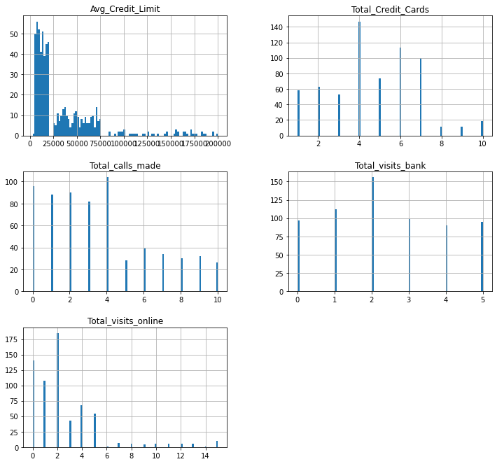

```python
#Univariate plots of predictor and target variables
columns = list(data)
data[columns].hist(stacked=False, bins=100, figsize=(12,40), layout=(10,2));
# Histogram of first 8 columns
```

[output not shown]

```python
data.isnull().sum() # Checking if there are any null values in data set
```

```
Avg_Credit_Limit       0
Total_Credit_Cards     0
Total_visits_bank      0
Total_visits_online    0
Total_calls_made       0
dtype: int64
```

```
No null entries
```

```python
#Checking for NaN entries in the dataset
data.isna().values.any()
```

```
False
```

```
No NaN entries in the dataset
```

```python
#number and percentage of outliers in each column
q1=data.quantile(0.25)
q3=data.quantile(0.75)
IQR=q3-q1
cwo=((data.iloc[:] <(q1-1.5*IQR))|(data.iloc[:]>(q3+1.5*IQR))).sum(axis=0)
opdf=pd.DataFrame(cwo,index=data.columns,columns=['No. of Outliers'])
opdf['Percentage Outliers']=round(opdf['No. of Outliers']*100/len(data),2)
opdf
```

|  | No. of Outliers | Percentage Outliers |
| --- | --- | --- |
| Avg_Credit_Limit | 38 | 5.86 |
| Total_Credit_Cards | 0 | 0.00 |
| Total_visits_bank | 0 | 0.00 |
| Total_visits_online | 37 | 5.70 |
| Total_calls_made | 0 | 0.00 |

```
Only "Avg_Credit_Limit" and "Total_visits_online" columns have outliers. "Avg_Credit_Limit" has the highest number of outliers with 5.86% of the entries in the column being outliers
```

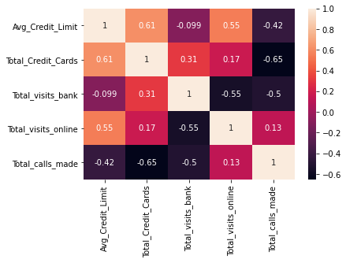

```python
#Correlation heat map between variables
corr = data.corr()
sns.heatmap(corr, annot = True)
```

```
Maximum correlation occurs between "Total_Credit_Cards" and "Total_calls_made" which is strong at 0.65. Also, there is a fair correlation between "Avg_Credit_Limit" and "Total_Credit_Cards". The weakest correlation occurs between "Avg_Credit_Limit" and "Total_visits_bank"
```

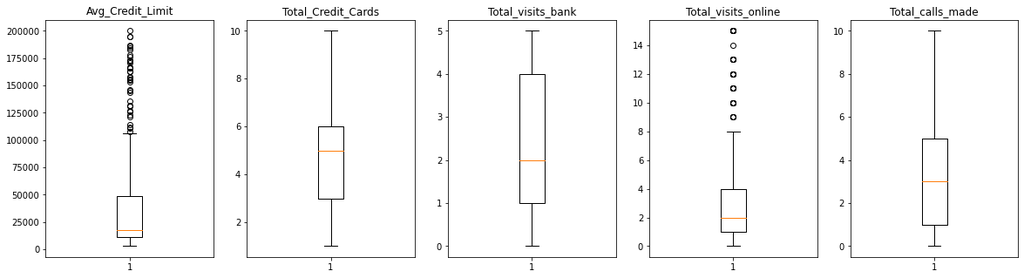

```python
#Box plots of all variables
plt.figure(figsize=(20,5))
graph_by_variables = ['Avg_Credit_Limit', 'Total_Credit_Cards', 'Total_visits_bank', 'Total_visits_online','Total_calls_made']
for i in range(0,5):
    plt.subplot(1, 5, i+1)
    plt.boxplot(data[graph_by_variables[i]].dropna())
    plt.title(graph_by_variables[i])
```

```
Only two columns have outliers
```

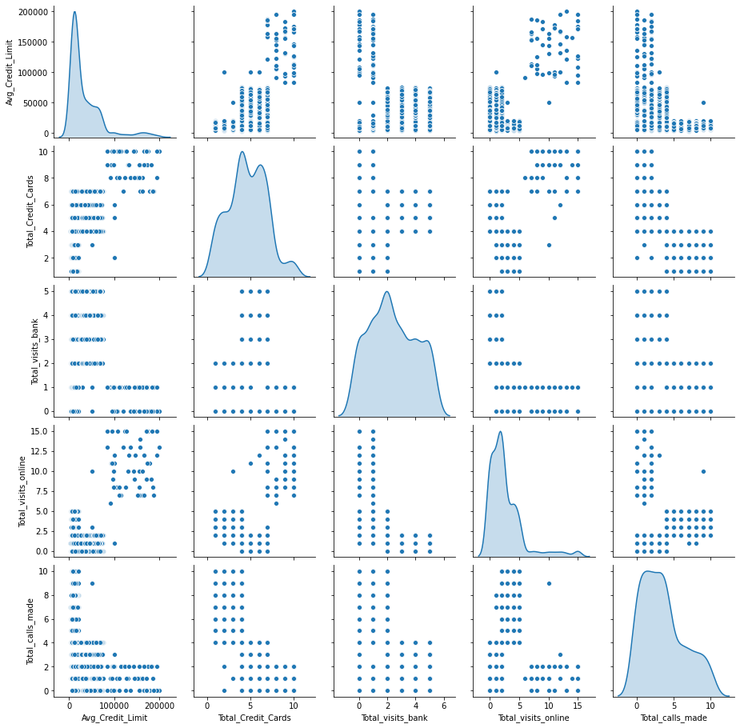

```python
#Bi-variate pairplots between variables using kernel density estimate
import seaborn as sns
sns.pairplot(data, diag_kind='kde')
```

```
From the above plots, "Total_Credit_Cards" and "Total_calls_made" shows some correlation. Also, there is a correlation between "Avg_Credit_Limit" and "Total_Credit_Cards". The peaks of the kde plots shows there should be a minimum of 4 clusters
```

#### 2. Properly comment on the codes, provide explanations of the steps taken in the notebook and conclude your insights from the graphs. (5 marks)

**Insights**

[output not shown]

#### 3. Execute K-means clustering use elbow plot and analyse clusters using boxplot (10 marks)

```python
#Scale the data to minimize the effect of larger units on some columns
from sklearn.preprocessing import StandardScaler
sc = StandardScaler()
data_std = pd.DataFrame(sc.fit_transform(data),columns=data.columns)
## Copy standardized data into another variable to avoid messing with original data
data_kmeans = data_std.copy()
```

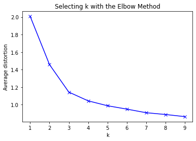

```python
#Plotting elbow curve for finding optimal no. of clusters
from scipy.spatial.distance import cdist
clusters=range(1,10)
meanDistortions=[]

for k in clusters:
    model=KMeans(n_clusters=k)
    model.fit(data_kmeans)
    prediction=model.predict(data_kmeans)
    meanDistortions.append(sum(np.min(cdist(data_kmeans, model.cluster_centers_, 'euclidean'), axis=1)) / data_kmeans
                           .shape[0])


plt.plot(clusters, meanDistortions, 'bx-')
plt.xlabel('k')
plt.ylabel('Average distortion')
plt.title('Selecting k with the Elbow Method')
```

```
From the plot, the error rate start to minimized from k = 3 and the first steepest decline occurs for this k . We will test for k between 3 and 6
```

For k = 3

```python
#Set the value of k=6
kmeans3 = KMeans(n_clusters=3, n_init = 15, random_state=2345)
```

```python
#Fit the kmeans on the data
kmeans3.fit(data_kmeans)
```

```
KMeans(n_clusters=3, n_init=15, random_state=2345)
```

```python
#Find centroids of the clusters
centroids3 = kmeans3.cluster_centers_
```

```python
#Calculate the centroids for the columns to profile for k=3
centroid3_df = pd.DataFrame(centroids3, columns = list(data_kmeans) )
```

```python
## creating a new dataframe only for labels and converting it into categorical variable
df_labels = pd.DataFrame(kmeans3.labels_ , columns = list(['KPlabel']))

df_labels['KPlabel'] = df_labels['KPlabel'].astype('category')
```

```python
# Joining the label dataframe with the data frame.
df_labeled = data_kmeans.join(df_labels)
```

```python
df_analysis = (df_labeled.groupby(['KPlabel'] , axis=0)).head(20000)  # the groupby creates a groupeddataframe that needs
# to be converted back to dataframe.
df_analysis.head()
```

|  | Avg_Credit_Limit | Total_Credit_Cards | Total_visits_bank | Total_visits_online | Total_calls_made | KPlabel |
| --- | --- | --- | --- | --- | --- | --- |
| 0 | 1.723499 | -1.247087 | -0.860606 | -0.550407 | -1.248443 | 1 |
| 1 | 0.400209 | -0.786701 | -1.476410 | 2.499808 | 1.881237 | 0 |
| 2 | 0.400209 | 1.054846 | -0.860606 | 0.127419 | 0.142526 | 1 |
| 3 | -0.129107 | 0.134072 | -0.860606 | -0.550407 | 0.142526 | 1 |
| 4 | 1.723499 | 0.594459 | -1.476410 | 3.177634 | -0.205216 | 2 |

```python
#Counts rows under each label category
df_labeled['KPlabel'].value_counts()
```

```
1    378
0    221
2     50
Name: KPlabel, dtype: int64
```

```python
# Fitting final model with K = 3
final_model=KMeans(3)
final_model.fit(data_kmeans)
prediction=final_model.predict(data_kmeans)

#Append the prediction
data_kmeans["KPlabel"] = prediction
print("Groups Assigned : \n")
data_kmeans[["Total_Credit_Cards", "KPlabel"]]
```

```
Groups Assigned :
```

|  | Total_Credit_Cards | KPlabel |
| --- | --- | --- |
| 0 | -1.247087 | 2 |
| 1 | -0.786701 | 0 |
| 2 | 1.054846 | 2 |
| 3 | 0.134072 | 2 |
| 4 | 0.594459 | 1 |
| ... | ... | ... |
| 644 | 2.436005 | 1 |
| 645 | 2.436005 | 1 |
| 646 | 1.515232 | 1 |
| 647 | 2.436005 | 1 |
| 648 | 1.975619 | 1 |

649 rows × 2 columns

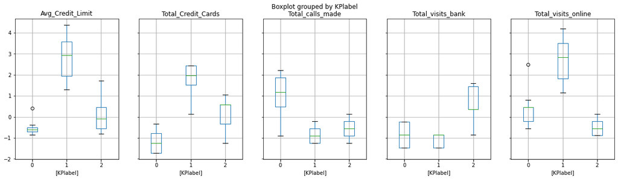

```python
#Box plots for categories when k=3
data_kmeans.boxplot(by = 'KPlabel',  layout=(1,5), figsize=(20, 5))
plt.show()
```

For k = 4, 5 and 6

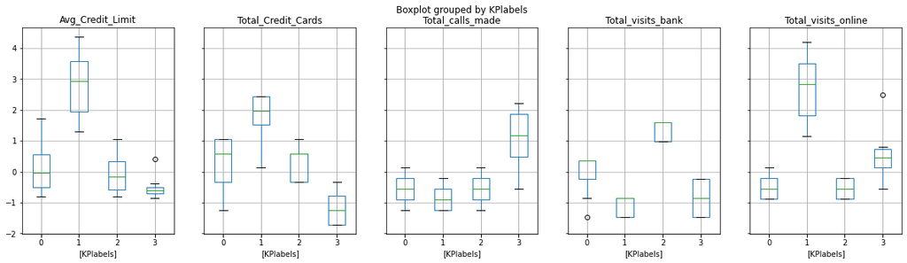

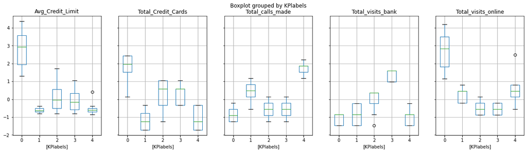

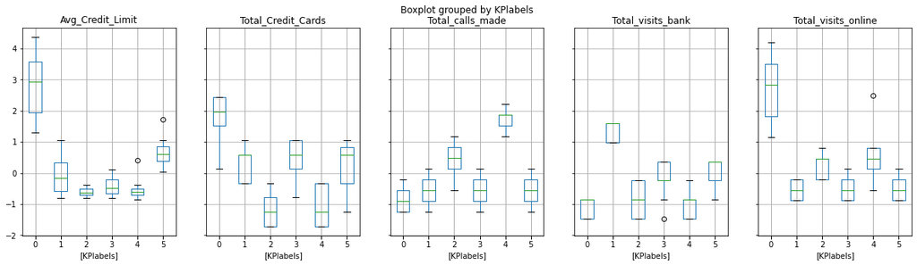

```python
k = [4,5,6]
data_kmean = data_kmeans.drop("KPlabel", 1)
for i in k:
    final_model=KMeans(i)
    final_model.fit(data_kmean)
    prediction=final_model.predict(data_kmean)

#Append the prediction
    data_kmean["KPlabels"] = prediction
    data_kmean.boxplot(by = 'KPlabels',  layout=(1,5), figsize=(20, 5))
```

In cell 33, cluster box plot for k=4,5 and 6 are shown from top to down order. By assesing the box plots in cells 32 and 33, it is obvious that minimal interaction between the newly formed clusters occurs when the number of clusters, k = 3.

#### 4. Execute hierarchical clustering (with different linkages) with the help of dendrogram and cophenetic coeff. Analyse clusters formed using boxplot (15 marks)

```python
# Copy standardized data into another variable to avoid messing with original data
data_hier = data_std.copy()
```

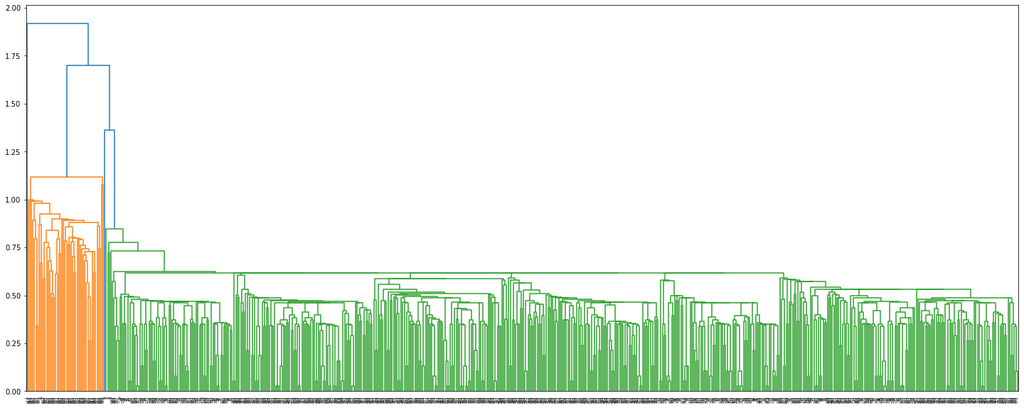

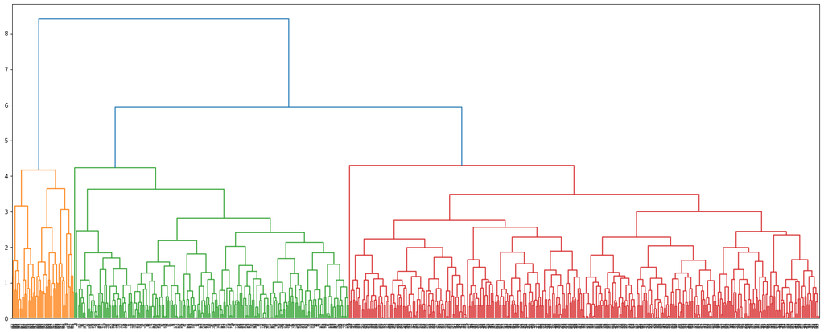

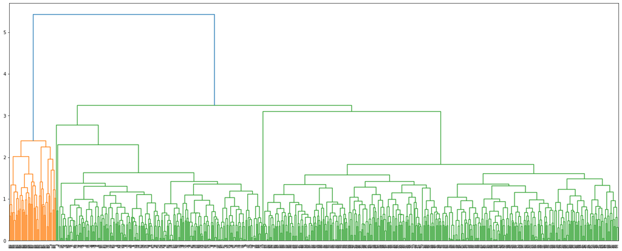

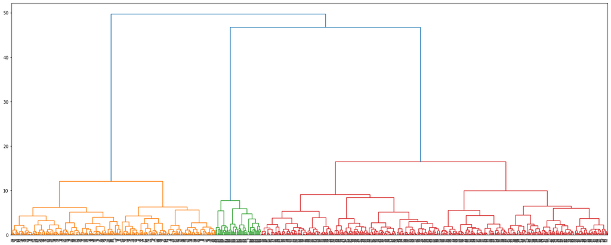

```python
# generate the linkage matrix and plots for atleast 4 linkage methods
from scipy.cluster.hierarchy import cophenet, dendrogram, linkage
linkages = ['single','complete','average','ward']
for i in linkages:
    Z = linkage(data_hier, i, metric='euclidean')
    plt.figure(figsize=(25, 10))
    #fig, ax_lst = plt.subplots(1, 1)
    dendrogram(Z)
    plt.show()
```

In the cell above, the dendrograms shown are for 'single','complete','average','ward' linkages in top to bottom order

```python
#Calculate cophenetic coefficient for atleast 4 linkage methods and store to a dataframe

from scipy.spatial.distance import pdist  #Pairwise distribution between data points

linkages = ['single','complete','average','ward']
cophenetic_coef = []
for i in linkages:
    Z = linkage(data_hier, i, metric='euclidean')
    cc,coph_dist = cophenet(Z, pdist(data_hier))
    cophenetic_coef.append((i,cc))
cophenetic_coef_df = pd.DataFrame({"CopCoefficient":cophenetic_coef, "Linkage":linkages})
cophenetic_coef_df
#The one with the hieghest coph is the best
```

|  | CopCoefficient | Linkage |
| --- | --- | --- |
| 0 | (single, 0.7395135051413775) | single |
| 1 | (complete, 0.8794736468795109) | complete |
| 2 | (average, 0.8974425535306298) | average |
| 3 | (ward, 0.7425813590948763) | ward |

```
From the above dataframe, the Linkage with highest cophenetic coefficient would be used. In this case, the average linkage method with about 90% cophenetic coefficient would be used. In other words, the eucleadean and dendrogramic distance are closest for the average linkage method
```

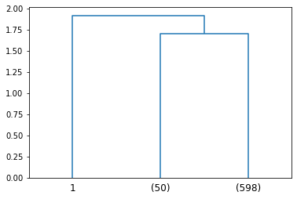

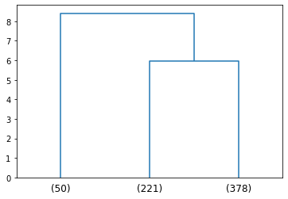

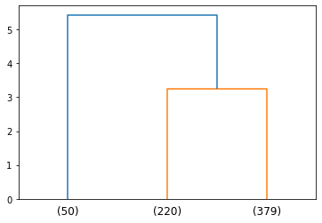

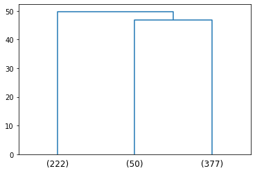

```python
# show only the last p merged clusters p=3,  # show only the last p merged clusters
linkages = ['single','complete','average','ward']
for i in linkages:
    Z = linkage(data_hier, i, metric='euclidean')
    dendrogram(Z,truncate_mode='lastp', p=3,)
    plt.show()
```

```
From the third plot in the above cell, it can be seen that for p=3, max_d = 3.2. Above this value, the number of clusters reduces to 2
```

For p = 3 and average as linkage, max_d = 3.2

```python
#Use this distance measure(max_d =3.2) and fcluster function to cluster the data into 3 different groups
from scipy.cluster.hierarchy import fcluster
Z = linkage(data_hier, 'average', metric='euclidean')
clusters = fcluster(Z, 3.2, criterion='distance')
clusters
```

[output not shown]

```
Above cell shows array of clusters for three different groups
```

```python
from sklearn.cluster import AgglomerativeClustering

hier_clus = AgglomerativeClustering(n_clusters=3, affinity='euclidean', linkage='average')
clusterheir = hier_clus.fit_predict(data_hier)

data_hier['heir_label'] = clusterheir
data_hier['heir_label'].value_counts()
```

```
0    379
2    220
1     50
Name: heir_label, dtype: int64
```

```
Uneven distribution of the data across the clusters is observed
```

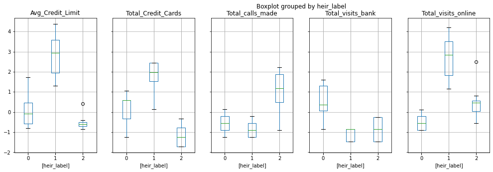

```python
#Box Plot for hierachiecal clustering
data_hier.boxplot(by = 'heir_label',  layout=(1,6), figsize=(20, 5))
plt.show()
```

```
The plots in the above cell is a repersentation of the dataset labeled in clusters using hierachical clustering algorithm
```

#### 5. Calculate average silhouette score for both methods. (5 marks)

```python
# Calculate Avg Silhoutte Score for  k=3, Linkage = Average and max_d=3.3 from Hierachical clustering
from sklearn.metrics import silhouette_score
silhouette_score(data_std, clusters)
```

```
0.5164769161012985
```

```python
#Calculate silhout score for k=3 from kmeans clustering techniques
kmeans = KMeans(n_clusters=3, random_state=40).fit_predict(data_std)
silhouette_score = metrics.silhouette_score(data_std, kmeans, metric='euclidean')
silhouette_score
```

```
0.516281010855363
```

```
The silhouette score for both methods in cells 41 and 42 are the same to three decimal places. This represents a good score.
```

#### 6. Compare K-means clusters with Hierarchical clusters. (5 marks)

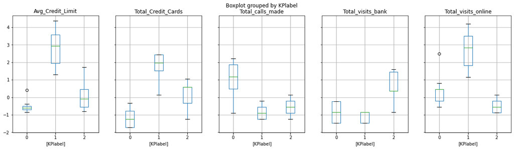

```python
#Box Plot for Kmeans clustering
data_kmeans.boxplot(by = 'KPlabel',  layout=(1,5), figsize=(20, 5))
plt.show()
```

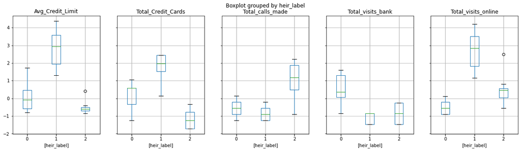

```python
#Box Plot for hierachical clustering
data_hier.boxplot(by = 'heir_label',  layout=(1,5), figsize=(20, 5))
plt.show()
```

[output not shown]

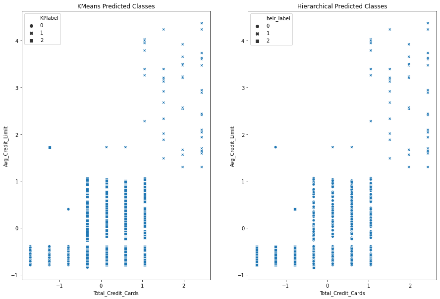

```python
#Comparison plot of two variable columns using predicted class for Kmeans and Hierachical clustering
fig, (ax1,ax2) = plt.subplots(1,2, figsize=(15,10))

ax1 = plt.subplot(1,2,1)
plt.title('KMeans Predicted Classes')
sns.scatterplot(x='Total_Credit_Cards', y='Avg_Credit_Limit', style='KPlabel', data=data_kmeans,ax=ax1)

ax2 = plt.subplot(1,2,2)
plt.title('Hierarchical Predicted Classes')
sns.scatterplot(x='Total_Credit_Cards', y='Avg_Credit_Limit', style = 'heir_label', data=data_hier, ax=ax2)

plt.show()
```

[output not shown]

#### 7. Analyse the clusters formed, tell us how is one cluster different from another and answer all the key questions. (10 marks)

1. How many different segments of customers are there?
2. How are these segments different from each other?
3. What are your recommendations to the bank on how to better market to and service these customers?
1. By using kmeans clustering techniques including analysing elbow curve and box plots (cell 22 to 33), the different segments of customers were observed to be 3 segments. We will call them Customer 1, Customer 2 and Customer 3.
2. From box plot in cell 44, one can deduce the following:

   ```
   Customer 0:Medium user of Credit Cards, contacts bank regularly (physically) but does not use online services regularly.

   Customer 1:High user of Credit Cards, uses online services the most but doesnt contact bank regularly.

   Customer 2:Low user of Credit Cards, contacts bank regularly (calls) and medium user of online services.
   ```

3. These recommendations are made assuming there is a very low risk of a default, where increase in credit limit will lead to more interest and as a result more returns to the bank:

   ```
    For Customer 0: Advertise benefits of using online tools such as flexibility, rebates etc and also sensitize customers on the benefits of not defaulting.

    For Customer 1: Potential high income earners, they should be targeted with ad campaigns for high value low risk investments eg investment in the bank's stock.

    For Customer 2: Create incentives to make this category of customers increase their credit limit e.g offering more friendly repayment plans such as yearly financing. Also advise customer to use more online tools in order not to miss out on important ad campaigns.
   ```